# 19. Дифференцируемые функции

Пусть $ f $ оперделена на $ (a, b), x_0 \in (a, b) $

### Определение 1

Пусть $ \Delta x \in \mathbb{R} $, т.ч. $ x_0 + \Delta x \in (a, b) $. Число $ \Delta x $ называется приращением аргумента. Число $ \Delta f = f(x_0 + \Delta x) - f(x_0) $ называется приращением функции, соответствующим приращению $ \Delta x $

Выразение $ \lim\limits_{x \to x_0} \frac{f(x)}{\Delta x} = \lim\limits_{\Delta x \to 0} \frac{f(x_0 + \Delta x) - f(x_0)}{\Delta x} $ называется производной функции $ f $ в точке $ x_0 $ и обозначается $ \frac{df}{dx}|_{x=x_0} $

### Определение 2

Левой (правой) производной функции $ f $ в точке $ x_0 $ называется выражение $ f_-'(x+0) = \lim\limits_{\Delta x \to 0 - 0} \frac{f(x_0 + \Delta x) - f(x_0)}{\Delta x} $

$ f_+'(x+0) = \lim\limits_{\Delta x \to 0 + 0} \frac{f(x_0 + \Delta x) - f(x_0)}{\Delta x} $

### Утверждение 1

$ \exists f'(x_0) \Leftrightarrow \exists f_-'(x_0), f_+'(x_0), \ f_-'(x_0) = f_+'(x_0) $

Пример:

$ y = |x| $

$ f_-'(0) = -1, f_+'(0) = 1 \Rightarrow \nexists f'(x) $

### Определение 3

Функция $ f $ называется дифференцируемой в точке $ x_0 $, если $ \exists A \subset X $, т.ч. $ \Delta f = f(x_0 + \Delta x) - f(x_0) $ представимо в виде $ \Delta f = A \cdot \Delta x + a(\Delta x)\cdot \Delta x $, гдe $ a(\Delta x) \to 0. A $ - постоянная, не зависящая от $ \Delta x $

### Теорема 1

Функция $ f $ дифференцируема в точке $ x_0 \Leftrightarrow \exists f'(x_0) $

$ \Rightarrow \Delta f = A\Delta x + a(\Delta x)\cdot \Delta x \Rightarrow \lim\limits{\Delta x \to 0} \frac{\Delta f}{\Delta x} = \lim\limits{\Delta x \to 0} (A + a(\Delta x)) = A \Rightarrow \exists f'(x_0) = A $

$ \Leftarrow $ Пусть $ \lim\limits{\Delta x \to 0} \frac{\Delta f}{\Delta x} = f'(x_0) \Rightarrow \left ( \frac{\Delta f}{\Delta x} - f'(x_0) \right ) \to 0 \Rightarrow \frac{\Delta f}{\Delta x} - f'(x_0) = a(\Delta x), $ где $ a(\Delta x) \to 0 \Rightarrow \Delta f = A \cdot \Delta x + a(\Delta x)\cdot \Delta x $

Таким образом, если $ f $ дифференцируема в точке $ x_0 $, то $ \Delta f = f(x_0)\Delta x + a(\Delta x)\Delta x, a(\Delta x) \to 0, \Delta x \to 0 $

### Утверждение 2

Пусть $ f $ дифференцируема в точке $ x_0 $. Тогда она непрерывна в ней

$ \Delta f =f(x_0 + \Delta x) - f(x_)) = f'(x_0)\Delta x + a(\Delta x)\Delta x\to 0 \Rightarrow f(x_0 + \Delta x) \to f(x_0) $, т.е. функция непрерывна в точке $ x_0 $

### Замечение

Из непрерывности функции в точке не следует её дифференцируемость в этой точке.

Пример: $ y = |x|, |x_0| = 0 $

### Геометрический смысл производной

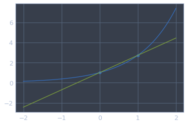

```python
import numpy as np
import matplotlib.pyplot as plt

# TODO: lib for graphics in calculus lectures

x = np.linspace(-2, 2, 200)
y = np.exp(x)
plt.plot(x, y)

coefficients = np.polyfit([0, 1], np.exp((0, 1)), 1)
polynomial = np.poly1d(coefficients)

line = polynomial(x)

plt.plot(x, line)
plt.scatter((0, 1), np.exp((0, 1)))
```

Обозначим $ \phi(\Delta x) $ угол между секущей и положительным направлением оси $O_x$. Тогда $ \exists \lim\limits_{\Delta x \to 0} \phi(\Delta x) = \phi_0 $, то $ \phi_0 $ - угол между касательной и осью $ O_x $

### Теорема 2 (геометрический смысл производной)

Если $ f $ дифференцируема в точке $ x_0 $, то в точке $ M(x_0, f(x_0)) $ существует касательная к графику функции, причём $ f'(x_0) =tg \phi_0 $

### Уравнение касательной

$ y = f'(x_0) (x - x_0) + f(x_0) $

### Замечание

Если $ f'(x) = \pm \infty $, то это значит, что $ \phi_0 = \pm \frac{\pi}{2} $, т.е. касательная в точке $ x_0 $ вертикальна. Её уравнение: $ x = x_0 $

Например:  
$ y = \sqrt[3]{x} $ имеет в точке $ x_0 = 0 $ вертикальную касательную $ x = 0 $

## Правила дифференцирования

### Теорема 3 (о сложной функции)

Пусть $ \phi: (\alpha, \beta) \to (a, b); f: (a, b) \to X. t_0 \in (\alpha, \beta), x_0 = \phi(t_0) $. Если $ \phi $ определена в точке $ t_0 $, $ f $ оперделена в точке $ x_0 $, то сложная функция дифференцируема в точке $ t_0 $ и $ (f(\phi(t_0)))' = f'(x_0)\phi'(t_0) $

$ \Delta t \in \mathbb{R}, t_0 + \Delta t \in (\alpha, \beta). $ Тогда $ \phi(t_0 + \Delta t) - \phi(t_0) = \phi(t_0)\Delta t + \alpha(\Delta t)\Delta t, \ \alpha(\Delta t) \to 0 $

Обозначим $ \Delta x = \phi(t_0 + \Delta t) - \phi(t_0) $, тогда $ x_0 + \Delta x \in (a, b) \Rightarrow f(x_0 = \Delta x) - f(x_)) = f'(x_0)\Delta x + \beta(\Delta x)\Delta x, \ \beta(\Delta x) \to 0$

$ = f'(x_0)(\phi(t_0)\Delta t + \alpha(\Delta t)\Delta t) + \beta(\Delta x)(\phi(t_0)\Delta t + \alpha(\Delta t)\Delta t) = \dots $

### Теорема 4 (производная обратной функции)

Пусть функция $ f $ определанвб непрерывна и строго монотонна в $ B_\delta(x_0) $ для некоторого $ \delta > 0 $. Если $ \exists f'(x_0) \neq 0, $ то в точке $ y_0 = f(x_0) $ существует производная обратной функции: $ (f^{-1}(y))' = \frac{1}{f'(x)} $

Пусть $ \Delta x \in \mathbb{R} \backslash \{0\}, x_0 + \Delta x = B_\delta(x_0) $. По теореме об обратной функции в некоторой окрестности точки $ y_0 = f(x_0) $ существует обратная функция $ f^{-1}(y) $. Полодим $ \Delta y = f(x_0 + \Delta x) - f(x_0). $ Тогда $ \Delta y \neq 0 $ ( $ f $ строгомонотонна), причём $ f^{-1}(y_0 + \Delta y) - f^{-1}(y_0) = f^{-1}(f(f(x_0) + x_0 + \Delta x) - f(x_0)) - x_0 = f^{-1}(f(x_0 + \Delta x)) - x_0 = x_0 + \Delta x - x_0 = \Delta x $

Значит $(f^{-1}(y))'_{y = y_0} = \lim\limits{\Delta y \to 0} \frac{\Delta x}{\Delta y} = \frac{1}{\lim\limits{\Delta y \to 0} \frac{\Delta x}{\Delta y}} = \frac{1}{f'(x)}$

### Теорема 5

Пусть $ f, g $ дифференцируемы в точке $ x_0 $. Тогда $ f(x \pm g(x))' = f'(x) \pm g'(x), (f(x)\cdot g(x))' = f(x)g'(x) + f'(x)g(x) $б если $ g(x) \neq 0, \frac{f(x)}{g(x)}' = \frac{f'(x)g(x) - f(x)g'(x)}{g^2(x)} $

$ h = f \pm g \Rightarrow \frac{\Delta h}{\Delta x} = \frac{\Delta f \pm \Delta g}{\Delta x} = \frac{\Delta f}{\Delta x} \pm \frac{\Delta g}{\Delta x} \to f(x) \pm g(x)$

$ h = fg \Rightarrow \frac{\Delta h}{\Delta x} = \frac{f(x_0 + \Delta x)g(x_0 +\Delta x) - f(x_0)g(x_0)}{\Delta x} = \frac{f(x_0 + \Delta x)g(x_0 +\Delta x) - f(x_0)g(x_0 + \Delta x)}{\Delta x} + \frac{f(x_0)g(x_0 +\Delta x) - f(x_0)g(x_0)}{\Delta x} = \frac{\Delta f}{\Delta x}g(x_0 + \Delta x) + f(x_0)\frac{\Delta g}{\Delta x} \to f'(x_0)g(x_0) + f(x_0)g(x_)) $